# HW_1_Kumar_Laxman

This notebook is made by Laxman Kumar (lakumar@syr.edu) as part of the submission of Homework 1.

### Link to The Dashboard

https://hw1-lakumar.herokuapp.com/

## Import libraries and dataset

**The first step is to import the necessary libraries**

```python
#pip install mlxtend
```

```python
import matplotlib.pyplot as plt
import seaborn as sns
import numpy as np
import pandas as pd
import mlxtend as ml
from mlxtend.frequent_patterns import apriori
from mlxtend.frequent_patterns import association_rules
from mlxtend.preprocessing import TransactionEncoder
%matplotlib inline
```

### Importing Data

```python
#reading the employee attrition csv file into a dataframe
df = pd.read_csv('employee_attrition.csv')
```

```python
df.head()
```

|  | Age | Attrition | BusinessTravel | DailyRate | Department | DistanceFromHome | Education | EducationField | EmployeeCount | EmployeeNumber | ... | RelationshipSatisfaction | StandardHours | StockOptionLevel | TotalWorkingYears | TrainingTimesLastYear | WorkLifeBalance | YearsAtCompany | YearsInCurrentRole | YearsSinceLastPromotion | YearsWithCurrManager |
| --- | --- | --- | --- | --- | --- | --- | --- | --- | --- | --- | --- | --- | --- | --- | --- | --- | --- | --- | --- | --- | --- |
| 0 | 30 | No | Travel_Rarely | 1358 | Sales | 16.0 | 1 | Life Sciences | 1 | 1479 | ... | 3.0 | 80 | 2 | 4.0 | 2 | 2 | 2 | 1 | 2.0 | 2 |
| 1 | 52 | No | Travel_Rarely | 1325 | Research & Development | 11.0 | 4 | Life Sciences | 1 | 813 | ... | 2.0 | 80 | 1 | 9.0 | 3 | 3 | 5 | 2 | 1.0 | 4 |
| 2 | 42 | No | Travel_Rarely | 462 | Sales | 14.0 | 2 | Medical | 1 | 936 | ... | 1.0 | 80 | 0 | 10.0 | 6 | 3 | 5 | 4 | 0.0 | 3 |
| 3 | 55 | No | Non-Travel | 177 | Research & Development | 8.0 | 1 | Medical | 1 | 1278 | ... | 4.0 | 80 | 1 | 34.0 | 3 | 3 | 33 | 9 | 15.0 | 0 |
| 4 | 35 | No | Travel_Rarely | 1029 | Research & Development | 16.0 | 3 | Life Sciences | 1 | 1529 | ... | 4.0 | 80 | 0 | 11.0 | 3 | 1 | 11 | 8 | 3.0 | 3 |

5 rows × 35 columns

```python
df.shape
```

```
(1176, 35)
```

### Explorative Data Analysis

```python
#this will give the all the stats of all the columns
df.describe()
```

|  | Age | DailyRate | DistanceFromHome | Education | EmployeeCount | EmployeeNumber | EnvironmentSatisfaction | HourlyRate | JobInvolvement | JobLevel | ... | RelationshipSatisfaction | StandardHours | StockOptionLevel | TotalWorkingYears | TrainingTimesLastYear | WorkLifeBalance | YearsAtCompany | YearsInCurrentRole | YearsSinceLastPromotion | YearsWithCurrManager |
| --- | --- | --- | --- | --- | --- | --- | --- | --- | --- | --- | --- | --- | --- | --- | --- | --- | --- | --- | --- | --- | --- |
| count | 1176.000000 | 1176.000000 | 1174.000000 | 1176.000000 | 1176.0 | 1176.000000 | 1176.000000 | 1176.000000 | 1176.000000 | 1175.000000 | ... | 1175.000000 | 1176.0 | 1176.000000 | 1174.000000 | 1176.000000 | 1176.000000 | 1176.000000 | 1176.000000 | 1175.000000 | 1176.000000 |
| mean | 36.960034 | 800.386905 | 9.495741 | 2.895408 | 1.0 | 1036.430272 | 2.704932 | 65.822279 | 2.740646 | 2.068936 | ... | 2.718298 | 80.0 | 0.795918 | 11.402896 | 2.809524 | 2.747449 | 6.918367 | 4.151361 | 2.125106 | 4.242347 |
| std | 9.071964 | 404.709216 | 10.251379 | 1.025685 | 0.0 | 600.681874 | 1.094128 | 20.292035 | 0.719277 | 1.109590 | ... | 1.084095 | 0.0 | 0.847033 | 8.368864 | 1.307697 | 0.691586 | 6.107140 | 3.501618 | 3.183567 | 7.210390 |
| min | 18.000000 | 102.000000 | 1.000000 | 1.000000 | 1.0 | 1.000000 | 1.000000 | 30.000000 | 1.000000 | 1.000000 | ... | 1.000000 | 80.0 | 0.000000 | 0.000000 | 0.000000 | 1.000000 | 0.000000 | 0.000000 | 0.000000 | 0.000000 |
| 25% | 30.000000 | 461.750000 | 2.000000 | 2.000000 | 1.0 | 499.750000 | 2.000000 | 48.000000 | 2.000000 | 1.000000 | ... | 2.000000 | 80.0 | 0.000000 | 6.000000 | 2.000000 | 2.000000 | 3.000000 | 2.000000 | 0.000000 | 2.000000 |
| 50% | 36.000000 | 796.000000 | 7.000000 | 3.000000 | 1.0 | 1032.500000 | 3.000000 | 66.000000 | 3.000000 | 2.000000 | ... | 3.000000 | 80.0 | 1.000000 | 10.000000 | 3.000000 | 3.000000 | 5.000000 | 3.000000 | 1.000000 | 3.000000 |
| 75% | 43.000000 | 1162.000000 | 14.000000 | 4.000000 | 1.0 | 1574.500000 | 4.000000 | 83.000000 | 3.000000 | 3.000000 | ... | 4.000000 | 80.0 | 1.000000 | 15.000000 | 3.000000 | 3.000000 | 9.000000 | 7.000000 | 2.000000 | 7.000000 |
| max | 60.000000 | 1499.000000 | 224.000000 | 5.000000 | 1.0 | 2068.000000 | 4.000000 | 100.000000 | 4.000000 | 5.000000 | ... | 4.000000 | 80.0 | 3.000000 | 114.000000 | 6.000000 | 4.000000 | 40.000000 | 18.000000 | 15.000000 | 219.000000 |

8 rows × 26 columns

```python
df.describe().loc['std'][df.describe().loc['std'] == 0]
```

```
EmployeeCount    0.0
StandardHours    0.0
Name: std, dtype: float64
```

Both the EmployeeCount and StandardHours doesn't have any variance and therefore we can remove this columns

```python
print(df['EmployeeCount'].value_counts())
print(df['StandardHours'].value_counts())
```

```
1    1176
Name: EmployeeCount, dtype: int64
80    1176
Name: StandardHours, dtype: int64
```

**Removing these two attributes since it does have any variance**

```python
df.drop(['EmployeeCount','StandardHours'],axis = 1,inplace = True)
```

```python
df.columns
```

```
Index(['Age', 'Attrition', 'BusinessTravel', 'DailyRate', 'Department',
       'DistanceFromHome', 'Education', 'EducationField', 'EmployeeNumber',
       'EnvironmentSatisfaction', 'Gender', 'HourlyRate', 'JobInvolvement',
       'JobLevel', 'JobRole', 'JobSatisfaction', 'MaritalStatus',
       'MonthlyIncome', 'MonthlyRate', 'NumCompaniesWorked', 'Over18',
       'OverTime', 'PercentSalaryHike', 'PerformanceRating',
       'RelationshipSatisfaction', 'StockOptionLevel', 'TotalWorkingYears',
       'TrainingTimesLastYear', 'WorkLifeBalance', 'YearsAtCompany',
       'YearsInCurrentRole', 'YearsSinceLastPromotion',
       'YearsWithCurrManager'],
      dtype='object')
```

This are our new column headers now after removing the feature with zero variance

### Plots to help us know the data better

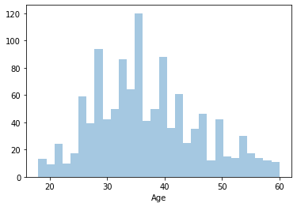

```python
sns.distplot(df['Age'],kde = False,bins = 30);
```

From the above plot, we can notice that most of the employee have ages between 25 to 45. Out data is widely spread between age 18 and age 60 and therefore we have to discretise the data into three groups

**We will discretise the age into three parts young adults, middle ages and elderly**

```python
print(df['Age'].min())
print(df['Age'].max())
```

```
18
60
```

```python
df['Age'] = pd.cut(df['Age'],bins = [17,35,50,70],labels = ['Young Adult','Middle Aged','Elderly'])
```

Above code replaces our spreaded data into 3 groups young adult, middle aged and elderly. We have used pandas cut function to accomplise this task

```python
df.head(3)
```

|  | Age | Attrition | BusinessTravel | DailyRate | Department | DistanceFromHome | Education | EducationField | EmployeeNumber | EnvironmentSatisfaction | ... | PerformanceRating | RelationshipSatisfaction | StockOptionLevel | TotalWorkingYears | TrainingTimesLastYear | WorkLifeBalance | YearsAtCompany | YearsInCurrentRole | YearsSinceLastPromotion | YearsWithCurrManager |
| --- | --- | --- | --- | --- | --- | --- | --- | --- | --- | --- | --- | --- | --- | --- | --- | --- | --- | --- | --- | --- | --- |
| 0 | Young Adult | No | Travel_Rarely | 1358 | Sales | 16.0 | 1 | Life Sciences | 1479 | 4 | ... | 3.0 | 3.0 | 2 | 4.0 | 2 | 2 | 2 | 1 | 2.0 | 2 |
| 1 | Elderly | No | Travel_Rarely | 1325 | Research & Development | 11.0 | 4 | Life Sciences | 813 | 4 | ... | 4.0 | 2.0 | 1 | 9.0 | 3 | 3 | 5 | 2 | 1.0 | 4 |
| 2 | Middle Aged | No | Travel_Rarely | 462 | Sales | 14.0 | 2 | Medical | 936 | 3 | ... | 3.0 | 1.0 | 0 | 10.0 | 6 | 3 | 5 | 4 | 0.0 | 3 |

3 rows × 33 columns

### Handling null values

```python
df.isna().sum()[df.isna().sum() > 0]
```

```
DistanceFromHome            2
Gender                      1
JobLevel                    1
OverTime                    1
PercentSalaryHike           1
PerformanceRating           1
RelationshipSatisfaction    1
TotalWorkingYears           2
YearsSinceLastPromotion     1
dtype: int64
```

**We will now build some plots for all the features with null or na values**

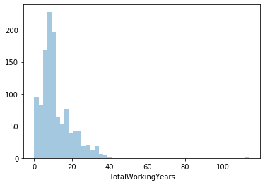

```python
sns.distplot(df['TotalWorkingYears'].dropna(),kde = False)
```

There appears to be some outlinears, we will take of those after taking care of na values

**Replacing the na values with the median**

```python
df[df['TotalWorkingYears'].isna()].index
```

```
Int64Index([82, 968], dtype='int64')
```

```python
rownum = [82, 968]

for num in rownum:
    df.at[num,'TotalWorkingYears'] = df['TotalWorkingYears'].median()
```

```python
#checking if the na has been replaced
df[df['TotalWorkingYears'].isna()]
```

|  | Age | Attrition | BusinessTravel | DailyRate | Department | DistanceFromHome | Education | EducationField | EmployeeNumber | EnvironmentSatisfaction | ... | PerformanceRating | RelationshipSatisfaction | StockOptionLevel | TotalWorkingYears | TrainingTimesLastYear | WorkLifeBalance | YearsAtCompany | YearsInCurrentRole | YearsSinceLastPromotion | YearsWithCurrManager |
| --- | --- | --- | --- | --- | --- | --- | --- | --- | --- | --- | --- | --- | --- | --- | --- | --- | --- | --- | --- | --- | --- |

0 rows × 33 columns

**From the above visualization, there appears to be an outlier**

```python
df[df['TotalWorkingYears'] > 70]['TotalWorkingYears']
```

```
143    114.0
Name: TotalWorkingYears, dtype: float64
```

**The outlier will be incorporated into the highest bin during descretization**

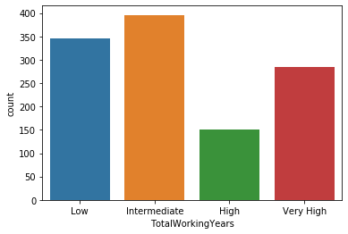

```python
labels = ['Low','Intermediate','High','Very High']
df['TotalWorkingYears'] = pd.qcut(df['TotalWorkingYears'],q = 4,labels = labels)
sns.countplot(x = 'TotalWorkingYears',data = df)
```

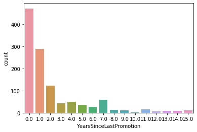

```python
#This is one of the feature which contains na values
sns.countplot(x = 'YearsSinceLastPromotion',data = df)
```

The data is right skewed with respect to YearsSinceLastPromotion.

```python
rownum = df[df['YearsSinceLastPromotion'].isna()].index[0]
df.at[rownum,'YearsSinceLastPromotion'] = df['YearsSinceLastPromotion'].median()
```

```python
df[df['YearsSinceLastPromotion'].isna()]
```

|  | Age | Attrition | BusinessTravel | DailyRate | Department | DistanceFromHome | Education | EducationField | EmployeeNumber | EnvironmentSatisfaction | ... | PerformanceRating | RelationshipSatisfaction | StockOptionLevel | TotalWorkingYears | TrainingTimesLastYear | WorkLifeBalance | YearsAtCompany | YearsInCurrentRole | YearsSinceLastPromotion | YearsWithCurrManager |
| --- | --- | --- | --- | --- | --- | --- | --- | --- | --- | --- | --- | --- | --- | --- | --- | --- | --- | --- | --- | --- | --- |

0 rows × 33 columns

We will replace the na with the median of the data in that particular feature. Cross checking whether the na has been replaced.

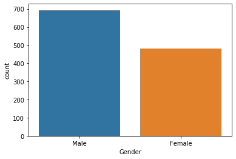

```python
#Third feature which contains the na values
sns.countplot(x = 'Gender',data = df)
```

From the above count plot, we have more male employees than female employees. We have 200 more male employees than female employees.

```python
#replacing the na with the mode
rownum = df[df['Gender'].isna()].index[0]

df.at[rownum,'Gender'] = df['Gender'].mode()
df[df['Gender'].isna()]
```

|  | Age | Attrition | BusinessTravel | DailyRate | Department | DistanceFromHome | Education | EducationField | EmployeeNumber | EnvironmentSatisfaction | ... | PerformanceRating | RelationshipSatisfaction | StockOptionLevel | TotalWorkingYears | TrainingTimesLastYear | WorkLifeBalance | YearsAtCompany | YearsInCurrentRole | YearsSinceLastPromotion | YearsWithCurrManager |
| --- | --- | --- | --- | --- | --- | --- | --- | --- | --- | --- | --- | --- | --- | --- | --- | --- | --- | --- | --- | --- | --- |

0 rows × 33 columns

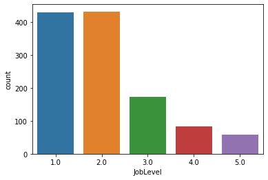

```python
#Fourth feature from the group of nas
sns.countplot(x = "JobLevel",data = df)
```

```python
#replacing the na with the median of the feature
rownum = df[df['JobLevel'].isna()].index[0]
df.at[rownum,'JobLevel'] = df['JobLevel'].median()
df[df['JobLevel'].isna()]
```

|  | Age | Attrition | BusinessTravel | DailyRate | Department | DistanceFromHome | Education | EducationField | EmployeeNumber | EnvironmentSatisfaction | ... | PerformanceRating | RelationshipSatisfaction | StockOptionLevel | TotalWorkingYears | TrainingTimesLastYear | WorkLifeBalance | YearsAtCompany | YearsInCurrentRole | YearsSinceLastPromotion | YearsWithCurrManager |
| --- | --- | --- | --- | --- | --- | --- | --- | --- | --- | --- | --- | --- | --- | --- | --- | --- | --- | --- | --- | --- | --- |

0 rows × 33 columns

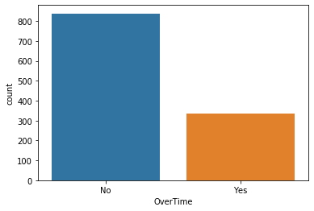

```python
#fifth feature from the list of feature with na
sns.countplot(x = "OverTime",data = df)
```

```python
#replacing the na with the mode
rownum = df[df['OverTime'].isna()].index[0]

df.at[rownum,'OverTime'] = df['OverTime'].mode()
#cross checking whether the na has been replaced
df[df['OverTime'].isna()]
```

|  | Age | Attrition | BusinessTravel | DailyRate | Department | DistanceFromHome | Education | EducationField | EmployeeNumber | EnvironmentSatisfaction | ... | PerformanceRating | RelationshipSatisfaction | StockOptionLevel | TotalWorkingYears | TrainingTimesLastYear | WorkLifeBalance | YearsAtCompany | YearsInCurrentRole | YearsSinceLastPromotion | YearsWithCurrManager |
| --- | --- | --- | --- | --- | --- | --- | --- | --- | --- | --- | --- | --- | --- | --- | --- | --- | --- | --- | --- | --- | --- |

0 rows × 33 columns

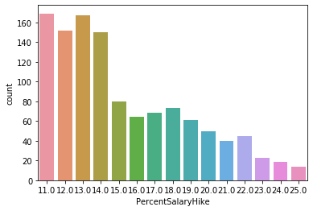

```python
#6th feature from the list of features with na
sns.countplot(x = 'PercentSalaryHike',data = df)
```

The data is right skewed with respect to percentsalary hike. The data lies between 11 percent to 25 percent. As we keep on increasing the percentage of hike the total count decreseas.

```python
#replacing with the median and cross checking
rownum = df[df['PercentSalaryHike'].isna()].index[0]

df.at[rownum,'PercentSalaryHike'] = df['PercentSalaryHike'].median()
df[df['PercentSalaryHike'].isna()]
```

|  | Age | Attrition | BusinessTravel | DailyRate | Department | DistanceFromHome | Education | EducationField | EmployeeNumber | EnvironmentSatisfaction | ... | PerformanceRating | RelationshipSatisfaction | StockOptionLevel | TotalWorkingYears | TrainingTimesLastYear | WorkLifeBalance | YearsAtCompany | YearsInCurrentRole | YearsSinceLastPromotion | YearsWithCurrManager |
| --- | --- | --- | --- | --- | --- | --- | --- | --- | --- | --- | --- | --- | --- | --- | --- | --- | --- | --- | --- | --- | --- |

0 rows × 33 columns

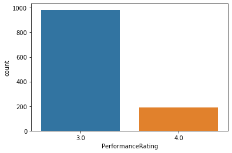

```python
#7th feature, performance rating which contains na
sns.countplot(x = 'PerformanceRating',data = df)
```

```python
#replacing the na's with the mode of the feature
rownum = df[df['PerformanceRating'].isna()].index[0]
df.at[rownum,'PerformanceRating'] = df['PerformanceRating'].mode()

#cross checking whether all the na's has been replaced with the mode
df[df['PerformanceRating'].isna()]
```

|  | Age | Attrition | BusinessTravel | DailyRate | Department | DistanceFromHome | Education | EducationField | EmployeeNumber | EnvironmentSatisfaction | ... | PerformanceRating | RelationshipSatisfaction | StockOptionLevel | TotalWorkingYears | TrainingTimesLastYear | WorkLifeBalance | YearsAtCompany | YearsInCurrentRole | YearsSinceLastPromotion | YearsWithCurrManager |
| --- | --- | --- | --- | --- | --- | --- | --- | --- | --- | --- | --- | --- | --- | --- | --- | --- | --- | --- | --- | --- | --- |

0 rows × 33 columns

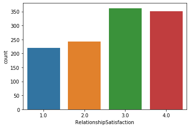

```python
#8th feature whose na has to be taken care of
sns.countplot(x = 'RelationshipSatisfaction',data = df)
```

```python
#replacing all the na with the mode
rownum = df[df['RelationshipSatisfaction'].isna()].index[0]

df.at[rownum,'RelationshipSatisfaction'] = df['RelationshipSatisfaction'].mode()
df[df['RelationshipSatisfaction'].isna()]
```

|  | Age | Attrition | BusinessTravel | DailyRate | Department | DistanceFromHome | Education | EducationField | EmployeeNumber | EnvironmentSatisfaction | ... | PerformanceRating | RelationshipSatisfaction | StockOptionLevel | TotalWorkingYears | TrainingTimesLastYear | WorkLifeBalance | YearsAtCompany | YearsInCurrentRole | YearsSinceLastPromotion | YearsWithCurrManager |
| --- | --- | --- | --- | --- | --- | --- | --- | --- | --- | --- | --- | --- | --- | --- | --- | --- | --- | --- | --- | --- | --- |

0 rows × 33 columns

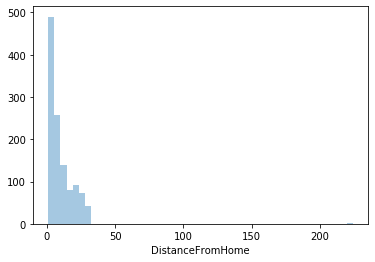

```python
#10th feature from the group of features with na
sns.distplot(df['DistanceFromHome'].dropna(),kde = False)
```

```python
#we will replace the na with the interpolated value
df['DistanceFromHome'].interpolate(inplace = True)
df['DistanceFromHome'].isna().value_counts()
```

```
False    1176
Name: DistanceFromHome, dtype: int64
```

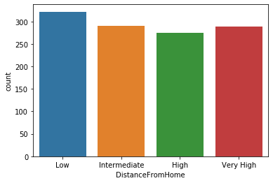

```python
#we will take care of the outlinears through discretisation
df['DistanceFromHome'] = pd.qcut(df['DistanceFromHome'],q = 4,labels = labels)
sns.countplot(x = 'DistanceFromHome',data = df)
```

```python
df.isna().sum()[df.isna().sum() > 0]
```

```
Series([], dtype: int64)
```

**We have taken care of all the features with na values. Now we will explore our rest of the features.**

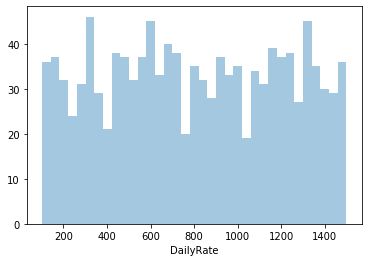

```python
sns.distplot(df['DailyRate'],kde = False,bins = 35)
```

```python
df['DailyRate'] = pd.qcut(df['DailyRate'],4,labels = labels)
```

```python
df.head()
```

|  | Age | Attrition | BusinessTravel | DailyRate | Department | DistanceFromHome | Education | EducationField | EmployeeNumber | EnvironmentSatisfaction | ... | PerformanceRating | RelationshipSatisfaction | StockOptionLevel | TotalWorkingYears | TrainingTimesLastYear | WorkLifeBalance | YearsAtCompany | YearsInCurrentRole | YearsSinceLastPromotion | YearsWithCurrManager |
| --- | --- | --- | --- | --- | --- | --- | --- | --- | --- | --- | --- | --- | --- | --- | --- | --- | --- | --- | --- | --- | --- |
| 0 | Young Adult | No | Travel_Rarely | Very High | Sales | Very High | 1 | Life Sciences | 1479 | 4 | ... | 3.0 | 3.0 | 2 | Low | 2 | 2 | 2 | 1 | 2.0 | 2 |
| 1 | Elderly | No | Travel_Rarely | Very High | Research & Development | High | 4 | Life Sciences | 813 | 4 | ... | 4.0 | 2.0 | 1 | Intermediate | 3 | 3 | 5 | 2 | 1.0 | 4 |
| 2 | Middle Aged | No | Travel_Rarely | Intermediate | Sales | High | 2 | Medical | 936 | 3 | ... | 3.0 | 1.0 | 0 | Intermediate | 6 | 3 | 5 | 4 | 0.0 | 3 |
| 3 | Elderly | No | Non-Travel | Low | Research & Development | High | 1 | Medical | 1278 | 4 | ... | 3.0 | 4.0 | 1 | Very High | 3 | 3 | 33 | 9 | 15.0 | 0 |
| 4 | Young Adult | No | Travel_Rarely | High | Research & Development | Very High | 3 | Life Sciences | 1529 | 4 | ... | 3.0 | 4.0 | 0 | High | 3 | 1 | 11 | 8 | 3.0 | 3 |

5 rows × 33 columns

```python
df['EmployeeNumber'].nunique()
```

```
1176
```

**Employee number is just a primary key in the database and can be removed since it will not affect out attrition**

```python
df.drop(['EmployeeNumber'],axis = 1,inplace = True)
```

```python
df.columns
```

```
Index(['Age', 'Attrition', 'BusinessTravel', 'DailyRate', 'Department',
       'DistanceFromHome', 'Education', 'EducationField',
       'EnvironmentSatisfaction', 'Gender', 'HourlyRate', 'JobInvolvement',
       'JobLevel', 'JobRole', 'JobSatisfaction', 'MaritalStatus',
       'MonthlyIncome', 'MonthlyRate', 'NumCompaniesWorked', 'Over18',
       'OverTime', 'PercentSalaryHike', 'PerformanceRating',
       'RelationshipSatisfaction', 'StockOptionLevel', 'TotalWorkingYears',
       'TrainingTimesLastYear', 'WorkLifeBalance', 'YearsAtCompany',
       'YearsInCurrentRole', 'YearsSinceLastPromotion',
       'YearsWithCurrManager'],
      dtype='object')
```

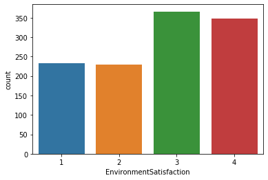

```python
sns.countplot(x = 'EnvironmentSatisfaction',data = df)
```

Above plot gives us the count of EnvironmentSatisfaction features and its distribution. Higher rating have more count in comparison with low rating.

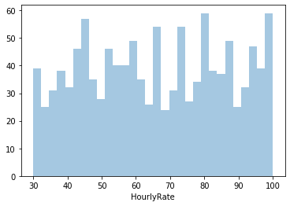

```python
sns.distplot(df['HourlyRate'],kde = False,bins = 30)
```

```python
df['HourlyRate'] = pd.qcut(df['HourlyRate'],4,labels = labels)
```

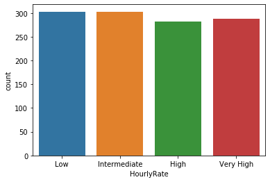

```python
sns.countplot(x = 'HourlyRate',data = df)
```

After discretising the HourlyRate feature, we can see that the data is evenly distributed among all the four divisions.

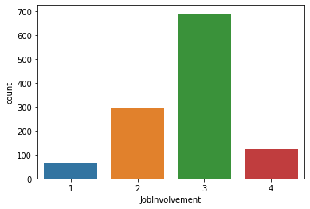

```python
sns.countplot(x = 'JobInvolvement',data = df)
```

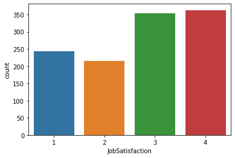

```python
sns.countplot(x = "JobSatisfaction",data = df)
```

Most of the employee had gave higher job satisfaction rating.

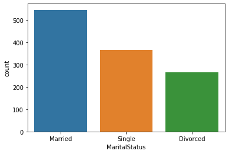

```python
sns.countplot(x = "MaritalStatus",data = df)
```

Employees with status as Married are higher in number while the employees with the status as Divorced are less in number.

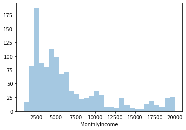

```python
sns.distplot(df["MonthlyIncome"],kde = False,bins = 30)
```

```python
df["MonthlyIncome"] = pd.qcut(df["MonthlyIncome"],q = 4,labels = labels)
```

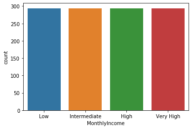

```python
sns.countplot('MonthlyIncome',data = df)
```

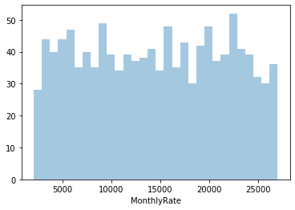

```python
sns.distplot(df["MonthlyRate"],kde = False,bins = 30)
```

```python
df["MonthlyRate"] = pd.qcut(df["MonthlyRate"],q = 4,labels = labels)
```

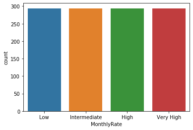

```python
sns.countplot('MonthlyRate',data = df)
```

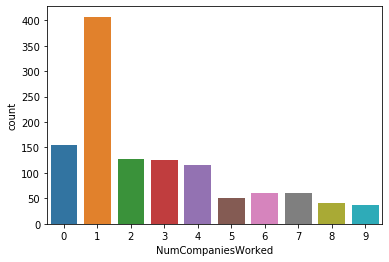

```python
sns.countplot('NumCompaniesWorked',data = df)
```

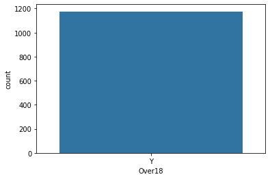

```python
sns.countplot(x = 'Over18',data = df)
```

```python
#this feature does not help since all the rows have similar data and hence we will remove this from our dataset
df['Over18'].value_counts()
```

```
Y    1176
Name: Over18, dtype: int64
```

```python
df.drop(['Over18'],axis = 1,inplace = True)
```

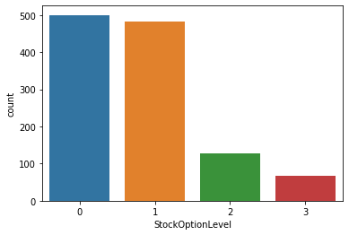

```python
sns.countplot(x = 'StockOptionLevel',data = df)
```

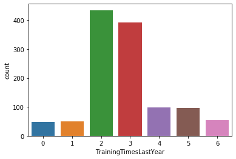

```python
sns.countplot(x = 'TrainingTimesLastYear',data = df)
```

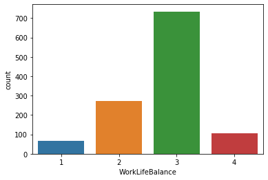

```python
sns.countplot(x = 'WorkLifeBalance',data = df)
```

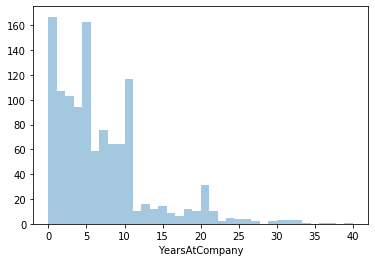

```python
sns.distplot(df['YearsAtCompany'],kde = False)
```

```python
df['YearsAtCompany'] = pd.qcut(df['YearsAtCompany'],q = 4,labels = labels)
```

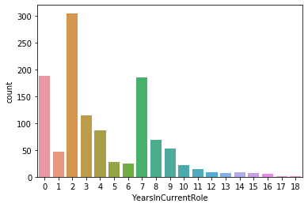

```python
sns.countplot(df['YearsInCurrentRole'],data = df)
```

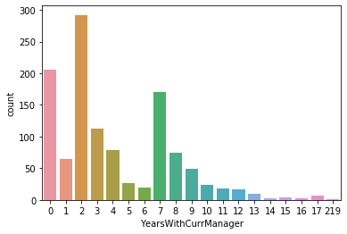

```python
sns.countplot(df['YearsWithCurrManager'],data = df)
```

```python
df['YearsWithCurrManager'].value_counts()
```

```
2      292
0      206
7      170
3      113
4       78
8       75
1       64
9       49
5       26
10      23
6       20
11      18
12      16
13       9
17       7
15       4
14       3
16       2
219      1
Name: YearsWithCurrManager, dtype: int64
```

```python
df['YearsWithCurrManager'] = pd.qcut(df['YearsWithCurrManager'],q = 4,labels = labels)
```

```python
df['YearsWithCurrManager'].head()
```

```
0             Low
1            High
2    Intermediate
3             Low
4    Intermediate
Name: YearsWithCurrManager, dtype: category
Categories (4, object): [Low < Intermediate < High < Very High]
```

## Data Preparation

```python
# convert dataframe to string
df = df.astype('str')

# Strip whitespaces
df[df.columns] = df.apply(lambda x: x.str.strip())

#Convert to type object
df = df.astype('object')
```

```python
#Create a dataframe consisting of column names
df1 = pd.DataFrame({col: str(col)+'=' for col in df}, index=df)
```

```python
# Concatenate column names from df1 to the values in df
for col in df.columns:
    df1[col] = df1[col].str.cat(df[col],sep =" ")
```

```python
df1.head(2)
```

|  | Age | Attrition | BusinessTravel | DailyRate | Department | DistanceFromHome | Education | EducationField | EnvironmentSatisfaction | Gender | ... | PerformanceRating | RelationshipSatisfaction | StockOptionLevel | TotalWorkingYears | TrainingTimesLastYear | WorkLifeBalance | YearsAtCompany | YearsInCurrentRole | YearsSinceLastPromotion | YearsWithCurrManager |
| --- | --- | --- | --- | --- | --- | --- | --- | --- | --- | --- | --- | --- | --- | --- | --- | --- | --- | --- | --- | --- | --- |
| (Young Adult, No, Travel_Rarely, Very High, Sales, Very High, 1, Life Sciences, 4, Male, Very High, 3, 2.0, Sales Executive, 3, Married, High, Low, 8, No, 15.0, 3.0, 3.0, 2, Low, 2, 2, Low, 1, 2.0, Lo… | Age= Young Adult | Attrition= No | BusinessTravel= Travel_Rarely | DailyRate= Very High | Department= Sales | DistanceFromHome= Very High | Education= 1 | EducationField= Life Sciences | EnvironmentSatisfaction= 4 | Gender= Male | ... | PerformanceRating= 3.0 | RelationshipSatisfaction= 3.0 | StockOptionLevel= 2 | TotalWorkingYears= Low | TrainingTimesLastYear= 2 | WorkLifeBalance= 2 | YearsAtCompany= Low | YearsInCurrentRole= 1 | YearsSinceLastPromotion= 2.0 | YearsWithCurrManager= Low |
| (Elderly, No, Travel_Rarely, Very High, Research & Development, High, 4, Life Sciences, 4, Female, High, 3, 2.0, Laboratory Technician, 3, Married, Intermediate, Very High, 8, No, 20.0, 4.0, 2.0, 1, I… | Age= Elderly | Attrition= No | BusinessTravel= Travel_Rarely | DailyRate= Very High | Department= Research & Development | DistanceFromHome= High | Education= 4 | EducationField= Life Sciences | EnvironmentSatisfaction= 4 | Gender= Female | ... | PerformanceRating= 4.0 | RelationshipSatisfaction= 2.0 | StockOptionLevel= 1 | TotalWorkingYears= Intermediate | TrainingTimesLastYear= 3 | WorkLifeBalance= 3 | YearsAtCompany= Intermediate | YearsInCurrentRole= 2 | YearsSinceLastPromotion= 1.0 | YearsWithCurrManager= High |

2 rows × 31 columns

```python
# Create a list out of the dataframe
records = []
for i in range(0,len(df1)):
    records.append([str(df1.values[i,j])
    for j in range(0, len(df1.columns))])
```

```python
#initialize transaction encoder
te = TransactionEncoder()
# Transform records
te_ary = te.fit(records).transform(records)
```

```python
#convert the transformed records to a dataframe
df2 = pd.DataFrame(te_ary, columns=te.columns_)
```

```python
df2.head()
```

|  | Age= Elderly | Age= Middle Aged | Age= Young Adult | Attrition= No | Attrition= Yes | BusinessTravel= Non-Travel | BusinessTravel= Travel_Frequently | BusinessTravel= Travel_Rarely | DailyRate= High | DailyRate= Intermediate | ... | YearsSinceLastPromotion= 4.0 | YearsSinceLastPromotion= 5.0 | YearsSinceLastPromotion= 6.0 | YearsSinceLastPromotion= 7.0 | YearsSinceLastPromotion= 8.0 | YearsSinceLastPromotion= 9.0 | YearsWithCurrManager= High | YearsWithCurrManager= Intermediate | YearsWithCurrManager= Low | YearsWithCurrManager= Very High |
| --- | --- | --- | --- | --- | --- | --- | --- | --- | --- | --- | --- | --- | --- | --- | --- | --- | --- | --- | --- | --- | --- |
| 0 | False | False | True | True | False | False | False | True | False | False | ... | False | False | False | False | False | False | False | False | True | False |
| 1 | True | False | False | True | False | False | False | True | False | False | ... | False | False | False | False | False | False | True | False | False | False |
| 2 | False | True | False | True | False | False | False | True | False | True | ... | False | False | False | False | False | False | False | True | False | False |
| 3 | True | False | False | True | False | True | False | False | False | False | ... | False | False | False | False | False | False | False | False | True | False |
| 4 | False | False | True | True | False | False | False | True | True | False | ... | False | False | False | False | False | False | False | True | False | False |

5 rows × 170 columns

## Association Rules With Default Hyperparameters

```python
# Create frequent itemsets using apriori
frequent_itemsets = apriori(df2,use_colnames=True)
```

```python
frequent_itemsets.sort_values(by='support',ascending=False).head(10)
```

|  | support | itemsets |
| --- | --- | --- |
| 0 | 0.842687 | (Attrition= No) |
| 6 | 0.837585 | (PerformanceRating= 3.0) |
| 1 | 0.713435 | (BusinessTravel= Travel_Rarely) |
| 5 | 0.712585 | (OverTime= No) |
| 12 | 0.709184 | (Attrition= No, PerformanceRating= 3.0) |
| 2 | 0.649660 | (Department= Research & Development) |
| 11 | 0.635204 | (Attrition= No, OverTime= No) |
| 7 | 0.624150 | (WorkLifeBalance= 3) |
| 8 | 0.612245 | (Attrition= No, BusinessTravel= Travel_Rarely) |
| 15 | 0.602891 | (BusinessTravel= Travel_Rarely, PerformanceRat... |

```python
#Create Association Rules
rules = association_rules(frequent_itemsets)
```

**The top values of the basic model can be seen below**

```python
rules.sort_values(by = 'lift',ascending=False).head(10)
```

|  | antecedents | consequents | antecedent support | consequent support | support | confidence | lift | leverage | conviction |
| --- | --- | --- | --- | --- | --- | --- | --- | --- | --- |
| 3 | (OverTime= No) | (Attrition= No) | 0.712585 | 0.842687 | 0.635204 | 0.891408 | 1.057816 | 0.034718 | 1.448662 |
| 13 | (OverTime= No, PerformanceRating= 3.0) | (Attrition= No) | 0.596088 | 0.842687 | 0.530612 | 0.890157 | 1.056332 | 0.028296 | 1.432161 |
| 1 | (Department= Research & Development) | (Attrition= No) | 0.649660 | 0.842687 | 0.567177 | 0.873037 | 1.036015 | 0.019717 | 1.239042 |
| 6 | (WorkLifeBalance= 3) | (Attrition= No) | 0.624150 | 0.842687 | 0.537415 | 0.861035 | 1.021774 | 0.011452 | 1.132036 |
| 12 | (PerformanceRating= 3.0, BusinessTravel= Trave... | (Attrition= No) | 0.602891 | 0.842687 | 0.518707 | 0.860367 | 1.020980 | 0.010659 | 1.126615 |
| 0 | (BusinessTravel= Travel_Rarely) | (Attrition= No) | 0.713435 | 0.842687 | 0.612245 | 0.858164 | 1.018367 | 0.011042 | 1.109122 |
| 2 | (JobInvolvement= 3) | (Attrition= No) | 0.586735 | 0.842687 | 0.503401 | 0.857971 | 1.018137 | 0.008968 | 1.107611 |
| 11 | (Attrition= No, BusinessTravel= Travel_Rarely) | (PerformanceRating= 3.0) | 0.612245 | 0.837585 | 0.518707 | 0.847222 | 1.011506 | 0.005900 | 1.063080 |
| 7 | (BusinessTravel= Travel_Rarely) | (PerformanceRating= 3.0) | 0.713435 | 0.837585 | 0.602891 | 0.845054 | 1.008917 | 0.005328 | 1.048201 |
| 4 | (Attrition= No) | (PerformanceRating= 3.0) | 0.842687 | 0.837585 | 0.709184 | 0.841574 | 1.004763 | 0.003362 | 1.025180 |

```python
rules.shape
```

```
(15, 9)
```

```python
# Function to set consequents and run association rules
def SupervisedApriori(data,consequent,min_supp,min_conf,min_lift):
    frequent_itemsets = apriori(data, min_supp, use_colnames=True)
    rules = association_rules(frequent_itemsets, metric="confidence", min_threshold=min_conf)
    #filter according to lift
    rules = rules[rules['lift'] > min_lift]
    sup_rules = pd.DataFrame()
    for i in consequent:
        df = rules[rules['consequents'] == {i}]
        sup_rules = sup_rules.append(df,ignore_index = True)
    return(sup_rules)
```

```python
SupervisedApriori(df2,consequent = ['Attrition= No','Attrition= Yes'],
min_supp=0.4, min_conf=0.7, min_lift=1).sort_values(by='support',ascending=False).head(5)
```

|  | antecedents | consequents | antecedent support | consequent support | support | confidence | lift | leverage | conviction |
| --- | --- | --- | --- | --- | --- | --- | --- | --- | --- |
| 5 | (PerformanceRating= 3.0) | (Attrition= No) | 0.837585 | 0.842687 | 0.709184 | 0.846701 | 1.004763 | 0.003362 | 1.026180 |
| 4 | (OverTime= No) | (Attrition= No) | 0.712585 | 0.842687 | 0.635204 | 0.891408 | 1.057816 | 0.034718 | 1.448662 |
| 0 | (BusinessTravel= Travel_Rarely) | (Attrition= No) | 0.713435 | 0.842687 | 0.612245 | 0.858164 | 1.018367 | 0.011042 | 1.109122 |
| 1 | (Department= Research & Development) | (Attrition= No) | 0.649660 | 0.842687 | 0.567177 | 0.873037 | 1.036015 | 0.019717 | 1.239042 |
| 6 | (WorkLifeBalance= 3) | (Attrition= No) | 0.624150 | 0.842687 | 0.537415 | 0.861035 | 1.021774 | 0.011452 | 1.132036 |

## Association Rules where 'Attrition = No'

```python
attrition_no = SupervisedApriori(df2,consequent = ['Attrition= No'],
min_supp=0.3, min_conf=0.9, min_lift=1)
```

```python
attrition_no.sort_values(by='lift',ascending=False).head(5)
```

|  | antecedents | consequents | antecedent support | consequent support | support | confidence | lift | leverage | conviction |
| --- | --- | --- | --- | --- | --- | --- | --- | --- | --- |
| 9 | (Department= Research & Development, OverTime=... | (Attrition= No) | 0.337585 | 0.842687 | 0.309524 | 0.916877 | 1.088039 | 0.025045 | 1.892522 |
| 11 | (Department= Research & Development, OverTime=... | (Attrition= No) | 0.379252 | 0.842687 | 0.346939 | 0.914798 | 1.085573 | 0.027348 | 1.846357 |
| 12 | (OverTime= No, PerformanceRating= 3.0, JobInvo... | (Attrition= No) | 0.346939 | 0.842687 | 0.316327 | 0.911765 | 1.081973 | 0.023966 | 1.782880 |
| 4 | (Department= Research & Development, OverTime=... | (Attrition= No) | 0.462585 | 0.842687 | 0.421769 | 0.911765 | 1.081973 | 0.031954 | 1.782880 |
| 6 | (MaritalStatus= Married, OverTime= No) | (Attrition= No) | 0.335034 | 0.842687 | 0.305272 | 0.911168 | 1.081264 | 0.022943 | 1.770894 |

## Association Rules where 'Attrition = Yes'

```python
attrition_yes = SupervisedApriori(df2,consequent = ['Attrition= Yes'],
min_supp=0.04, min_conf=0.4, min_lift=1)
```

**The below rules are the 5 most interesting because they have high lift values. Employees who have to work overtime,have low incomes/stock options,are in the early stages of their careers etc. Have a higher chance of leaving the company. This also goes along with our inituitive understanding, employees that spend long hours at work and aren't compensated highly are likely to look for opportunities elsewhere**

```python
attrition_yes.sort_values(by='lift',ascending=False).head(5)
```

|  | antecedents | consequents | antecedent support | consequent support | support | confidence | lift | leverage | conviction |
| --- | --- | --- | --- | --- | --- | --- | --- | --- | --- |
| 13 | (JobLevel= 1.0, OverTime= Yes, MonthlyIncome= ... | (Attrition= Yes) | 0.072279 | 0.157313 | 0.042517 | 0.588235 | 3.739269 | 0.031147 | 2.046526 |
| 3 | (MonthlyIncome= Low, OverTime= Yes) | (Attrition= Yes) | 0.075680 | 0.157313 | 0.042517 | 0.561798 | 3.571212 | 0.030612 | 1.923055 |
| 33 | (YearsAtCompany= Low, StockOptionLevel= 0, Age... | (Attrition= Yes) | 0.082483 | 0.157313 | 0.041667 | 0.505155 | 3.211145 | 0.028691 | 1.702930 |
| 46 | (YearsAtCompany= Low, YearsWithCurrManager= Lo... | (Attrition= Yes) | 0.082483 | 0.157313 | 0.041667 | 0.505155 | 3.211145 | 0.028691 | 1.702930 |
| 1 | (JobLevel= 1.0, OverTime= Yes) | (Attrition= Yes) | 0.102041 | 0.157313 | 0.049320 | 0.483333 | 3.072432 | 0.033267 | 1.631007 |